# Top differentially expressed LVs in GPA blood

**J. Taroni 2018**

Explore the top differentially expressed LVs in the GPA blood dataset (PBMCs). Are they pathways we could have captured with a PLIER model fit to this dataset?

## Functions and directory setup

```r
`%>%` <- dplyr::`%>%`
source(file.path("util", "plier_util.R"))
```

```r
# plot and result directory setup for this notebook
plot.dir <- file.path("plots", "22")
dir.create(plot.dir, recursive = TRUE, showWarnings = FALSE)
results.dir <- file.path("results", "22")
dir.create(results.dir, recursive = TRUE, showWarnings = FALSE)
```

## Load DLVE results

```r
limma.file <- file.path("results", "19",
                        "GPA_blood_recount2_model_LV_limma_results.tsv")
limma.df <- readr::read_tsv(limma.file)
```

Let’s take a look at the top differentially expressed latent variables. We’ll sort by FDR.

```r
limma.df %>%
  dplyr::filter(adj.P.Val < 0.05) %>%
  dplyr::arrange(adj.P.Val)
```

| LV | Control...GPAneg | Control...GPApos | GPAneg...GPApos | AveExpr | F | P.Value | adj.P.Val |
| --- | --- | --- | --- | --- | --- | --- | --- |
| 599,DMAP_ERY2 | -5.920821e-03 | -0.092968073 | -0.087047252 | 0.0299291894 | 37.764649 | 1.185996e-11 | 1.170578e-08 |
| 68,DMAP_ERY2 | 3.476042e-03 | -0.184488816 | -0.187964858 | -0.0276942463 | 35.205151 | 3.994481e-11 | 1.971276e-08 |
| 787,DMAP_MONO1 | -3.000581e-02 | -0.052580574 | -0.022574759 | 0.0469439420 | 20.103644 | 1.530567e-07 | 5.035565e-05 |
| LV 332 | -7.378086e-03 | 0.031956738 | 0.039334824 | 0.0198838022 | 18.362376 | 4.595030e-07 | 5.907386e-05 |
| LV 377 | 8.056443e-03 | 0.037785995 | 0.029729552 | 0.0469095368 | 18.674852 | 3.762090e-07 | 5.907386e-05 |
| 473,KEGG_COMPLEMENT_AND_COAGULATION_CASCADES | -4.337143e-03 | -0.042492329 | -0.038155186 | -0.0184669389 | 18.759005 | 3.565553e-07 | 5.907386e-05 |
| LV 544 | -1.231779e-02 | -0.035073025 | -0.022755235 | -0.0075957768 | 18.298289 | 4.788155e-07 | 5.907386e-05 |
| LV 624 | 2.930578e-03 | -0.042096900 | -0.045027479 | -0.0331296289 | 18.951515 | 3.154733e-07 | 5.907386e-05 |
| 524,IRIS_Neutrophil-Resting | -2.369790e-02 | -0.077438283 | -0.053740385 | -0.0751093684 | 16.429247 | 1.628160e-06 | 1.606994e-04 |
| LV 566 | 6.118941e-03 | -0.020082412 | -0.026201353 | -0.0429553419 | 16.446743 | 1.609269e-06 | 1.606994e-04 |

[output cut: 182 more lines]

Let’s explore `LV 599` a little further.

```r
recount.b.file <- file.path("results", "19",
                            "GPA_blood_recount2_model_B_long_sample_info.tsv")
recount.b.df <- readr::read_tsv(recount.b.file) %>%
  dplyr::mutate(GPA_signature =
                  dplyr::case_when(
                    GPA_signature == "GPApos" ~ "GPA-positive",
                    GPA_signature == "GPAneg" ~ "GPA-negative",
                    TRUE ~ "Control"
                  ))
```

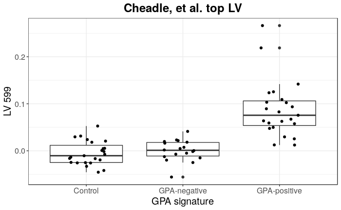

```r
recount.b.df %>%
  dplyr::filter(LV == "599,DMAP_ERY2") %>%
  ggplot2::ggplot(ggplot2::aes(x = GPA_signature, y = Value)) +
  ggplot2::geom_boxplot() +
  ggplot2::geom_jitter(position = ggplot2::position_jitter(0.2)) +
  ggplot2::theme_bw() +
  ggplot2::labs(x = "GPA signature", y = "LV 599",
                title = "Cheadle, et al. top LV") +
  ggplot2::theme(legend.position = "none",
                 text = ggplot2::element_text(size = 15),
                 plot.title = ggplot2::element_text(hjust = 0.5, face = "bold"))
```

```r
plot.file <- file.path(plot.dir, "recount2_LV599_boxplot.pdf")
ggplot2::ggsave(plot.file, plot = ggplot2::last_plot())
```

## Load recount2 PLIER model

```r
recount.plier <- readRDS(file.path("data", "recount2_PLIER_data",
                                   "recount_PLIER_model.RDS"))
```

### What are the pathways associated with `LV 599`?

```r
recount.plier$summary %>%
  dplyr::filter(`LV index` == 599)
```

| pathway | LV index | AUC | p-value | FDR |
| --- | --- | --- | --- | --- |
| DMAP_ERY2 | 599 | 0.7574218 | 1.758612e-04 | 0.0017893042 |
| DMAP_GMP | 599 | 0.3391214 | 8.290169e-01 | 0.9377032033 |
| DMAP_MONO1 | 599 | 0.7281707 | 4.144269e-05 | 0.0005197202 |
| SVM NK cells resting | 599 | 0.5152987 | 4.123662e-01 | 0.6389898702 |
| REACTOME_EXTRACELLULAR_MATRIX_ORGANIZATION | 599 | 0.3844385 | 9.365095e-01 | 0.9797023641 |
| PID_UPA_UPAR_PATHWAY | 599 | 0.4493574 | 6.979395e-01 | 0.8582984367 |
| PID_CMYB_PATHWAY | 599 | 0.6815647 | 1.600486e-03 | 0.0112668837 |

### What genes contribute to this LV (e.g., have the highest loadings)?

Let’s look at the top 50.

```r
head(sort(recount.plier$Z[, 599], decreasing = TRUE), 50)
```

```
      MPO     ELANE      AZU1     PRTN3     MS4A3      CPA3    RNASE2      CTSG      CST7      GFI1    RNASE3      PRG2  SLC22A16      CALR       HGF      SRGN     CYTL1       KIT
7.6287989 6.2953905 5.8638362 5.2984213 5.1141258 3.3066014 3.2086603 3.1774040 2.8926804 2.7491070 2.6836885 2.6471986 2.4480860 2.4046115 2.1717571 2.1278734 1.9043058 1.8300078
    NTNG2      P4HB      MEST     P2RY2       BPI    CITED2   EMILIN2       LYZ     F13A1   SLC28A3     IGLL1      MYCN     PRAM1     STAB1       CLC     CCNA1     DEFA4       CFD
1.6251605 1.6066455 1.5609102 1.5177552 1.4498729 1.4286242 1.3158223 1.2705287 1.2486816 1.2135985 1.1392354 1.1310816 1.0429996 1.0369828 1.0200808 0.9918391 0.9905232 0.9404843
     IRS2   CEACAM4       CAT       PNP     IRAK3    SLC1A3     SAP30    CLEC5A  SLC22A15   SLC22A4     RAB5B      TESC   CEACAM8      HCST
0.9340689 0.9048998 0.8877785 0.8471992 0.8457302 0.8006944 0.7867686 0.7589677 0.7544687 0.7486729 0.7355585 0.7346467 0.7325653 0.7274270
```

Some of these are major or minor autoantigens in ANCA-associated vasculitis. This is consistent with the original publication ([Cheadle, et al. *A&R.* 2010.](https://doi.org/10.1002/art.27398)): the authors found that “neutrophil granule constituent genes” were highly expressed in the PBMC fraction from patients with GPA that could not be attributed to contamination with mature granulocytes.

#### Plot highlighting autoantigens

We’ll use the list of autoantigens in Cheadle, et al.

```r
autoantigens <- c("MPO", "ELANE", "BPI", "CTSG", "LCN2", "AZU1", "PRTN3")
```

```r
# get into appropriate data.frame for bar plot
top.z.df <- as.data.frame(sort(recount.plier$Z[, 599],
                               decreasing = TRUE)[1:50])
top.z.df <- tibble::rownames_to_column(top.z.df, var = "Gene")
colnames(top.z.df)[2] <- "Z"
# add in autoantigen information
top.z.df <- top.z.df %>%
  dplyr::mutate(Autoantigen =
                  dplyr::case_when(
                    Gene %in% autoantigens ~ "Yes",
                    TRUE ~ "No"
                  ))
# reorder for plotting
top.z.df$Gene <- factor(top.z.df$Gene,
                        levels = top.z.df$Gene[50:1])
```

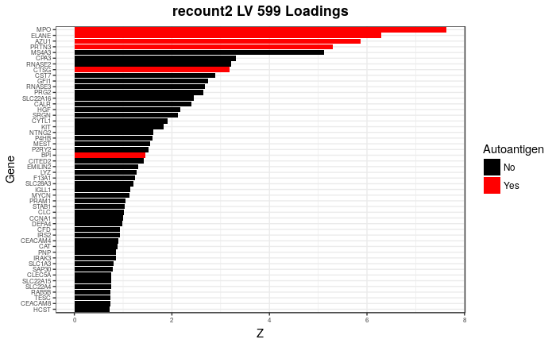

```r
p <- ggplot2::ggplot(top.z.df,
                ggplot2::aes(x = Gene, y = Z, fill = Autoantigen)) +
  ggplot2::geom_bar(stat = "identity") +
  ggplot2::theme_bw() +
  ggplot2::scale_fill_manual(values = c("black", "red")) +
  ggplot2::coord_flip() +
  ggplot2::ggtitle("recount2 LV 599 Loadings") +
  ggplot2::theme(plot.title = ggplot2::element_text(hjust = 0.5,
                                                    face = "bold"))
p + ggplot2::theme(axis.text = ggplot2::element_text(size = 6))
```

```r
plot.file <- file.path(plot.dir, "recount2_LV599_top_Z_bar.pdf")
ggplot2::ggsave(plot.file,
                plot = p +
                  ggplot2::theme(text = ggplot2::element_text(size = 15)),
                width = 6, height = 8)
```

## GPA Blood-specific PLIER model

Would we have detected this “autoantigen signature” using a PLIER model specifically trained on this GPA blood data?

```r
# remove objects we won't need for this next set of analyses
rm(limma.df, recount.b.df, limma.file, plot.file, recount.b.file,
   top.z.df)
```

### Read in expression data

```r
exprs.file <- file.path("data", "expression_data",
                        "GSE18885_annotated_mean.pcl")
agg.ma.df <- readr::read_tsv(exprs.file)
# get expression matrix
exprs.mat <- as.matrix(dplyr::select(agg.ma.df, -Gene))
rownames(exprs.mat) <- agg.ma.df$Gene
```

### Train PLIER model

```r
gpa.plier <- PLIERNewData(exprs.mat)
```

```
Removing 1 pathways with too few genesComputing SVD
Done
```

```
[1] 46.73248
[1] "L2 is set to 46.732480853389"
[1] "L1 is set to 23.3662404266945"
```

```
errorY (SVD based:best possible) = 0.1276
iter1 errorY= 0.9821, Bdiff= 8041, Bkappa=44.38
iter2 errorY= 0.4221, Bdiff= 0.733, Bkappa=66.01
iter3 errorY= 0.3073, Bdiff= 0.117, Bkappa=50.32
iter4 errorY= 0.3223, Bdiff= 0.03125, Bkappa=39.82
iter5 errorY= 0.3362, Bdiff= 0.01719, Bkappa=35.87
iter6 errorY= 0.3345, Bdiff= 0.0119, Bkappa=35.73
iter7 errorY= 0.3302, Bdiff= 0.008442, Bkappa=34.87
iter8 errorY= 0.3266, Bdiff= 0.006143, Bkappa=35.33
iter9 errorY= 0.3239, Bdiff= 0.004628, Bkappa=37.33
iter10 errorY= 0.3221, Bdiff= 0.003596, Bkappa=34.31
iter11 errorY= 0.3208, Bdiff= 0.002837, Bkappa=33.81
iter12 errorY= 0.32, Bdiff= 0.002287, Bkappa=35.92
iter13 errorY= 0.3196, Bdiff= 0.001885, Bkappa=37.48
iter14 errorY= 0.3194, Bdiff= 0.001611, Bkappa=37.42
iter15 errorY= 0.3194, Bdiff= 0.001431, Bkappa=35.62
iter16 errorY= 0.3195, Bdiff= 0.001309, Bkappa=44.48
iter17 errorY= 0.3195, Bdiff= 0.001214, Bkappa=44.1
iter18 errorY= 0.3195, Bdiff= 0.001136, Bkappa=38.53
iter19 errorY= 0.3195, Bdiff= 0.001065, Bkappa=35.94
Updating L3, current fraction= 0, target=0.7
L3 is set to 0.00586 in 9 iterations
iter20 errorY= 0.3168, prior information ratio= 0.01, Bdiff= 0.001051, Bkappa=35.96;pos. col. U=22
iter21 errorY= 0.3157, prior information ratio= 0.01, Bdiff= 0.001004, Bkappa=36.17;pos. col. U=22
iter22 errorY= 0.3151, prior information ratio= 0.01, Bdiff= 0.0009502, Bkappa=36.4;pos. col. U=21
iter23 errorY= 0.3146, prior information ratio= 0.01, Bdiff= 0.000896, Bkappa=36.59;pos. col. U=21
iter24 errorY= 0.3142, prior information ratio= 0.01, Bdiff= 0.0008584, Bkappa=31.44;pos. col. U=21
iter25 errorY= 0.3138, prior information ratio= 0.01, Bdiff= 0.000828, Bkappa=30.63;pos. col. U=21
iter26 errorY= 0.3134, prior information ratio= 0.02, Bdiff= 0.0007959, Bkappa=34.27;pos. col. U=21
iter27 errorY= 0.313, prior information ratio= 0.02, Bdiff= 0.0007541, Bkappa=34.52;pos. col. U=20
iter28 errorY= 0.3126, prior information ratio= 0.02, Bdiff= 0.0006987, Bkappa=36.15;pos. col. U=20
iter29 errorY= 0.3122, prior information ratio= 0.02, Bdiff= 0.0006339, Bkappa=34.4;pos. col. U=20
iter30 errorY= 0.3118, prior information ratio= 0.02, Bdiff= 0.0005679, Bkappa=34.83;pos. col. U=20
iter31 errorY= 0.3114, prior information ratio= 0.02, Bdiff= 0.000508, Bkappa=39.52;pos. col. U=20
iter32 errorY= 0.3112, prior information ratio= 0.02, Bdiff= 0.0004353, Bkappa=39.73;pos. col. U=20
iter33 errorY= 0.3109, prior information ratio= 0.02, Bdiff= 0.0003727, Bkappa=39.95;pos. col. U=20
iter34 errorY= 0.3106, prior information ratio= 0.02, Bdiff= 0.0003163, Bkappa=40.13;pos. col. U=20
iter35 errorY= 0.3105, prior information ratio= 0.02, Bdiff= 0.0002706, Bkappa=40.26;pos. col. U=20
iter36 errorY= 0.3103, prior information ratio= 0.02, Bdiff= 0.0002322, Bkappa=39.78;pos. col. U=21
iter37 errorY= 0.3102, prior information ratio= 0.02, Bdiff= 0.0002027, Bkappa=40.35;pos. col. U=21
```

[output cut: 140 more lines]

```
iter164 errorY= 0.3091, prior information ratio= 0.02, Bdiff= 2.177e-05, Bkappa=52.07;pos. col. U=22
iter165 errorY= 0.3091, prior information ratio= 0.02, Bdiff= 2.048e-05, Bkappa=52.17;pos. col. U=22
iter166 errorY= 0.3092, prior information ratio= 0.02, Bdiff= 1.924e-05, Bkappa=52.23;pos. col. U=22
iter167 errorY= 0.3092, prior information ratio= 0.02, Bdiff= 1.804e-05, Bkappa=52.25;pos. col. U=22
iter168 errorY= 0.3093, prior information ratio= 0.02, Bdiff= 1.688e-05, Bkappa=52.25;pos. col. U=22
iter169 errorY= 0.3093, prior information ratio= 0.02, Bdiff= 1.576e-05, Bkappa=52.23;pos. col. U=22
iter170 errorY= 0.3094, prior information ratio= 0.02, Bdiff= 1.468e-05, Bkappa=52.18;pos. col. U=22
iter171 errorY= 0.3094, prior information ratio= 0.02, Bdiff= 1.373e-05, Bkappa=52.12;pos. col. U=22
iter172 errorY= 0.3095, prior information ratio= 0.02, Bdiff= 1.275e-05, Bkappa=52.06;pos. col. U=22
iter173 errorY= 0.3095, prior information ratio= 0.02, Bdiff= 1.184e-05, Bkappa=51.96;pos. col. U=22
iter174 errorY= 0.3096, prior information ratio= 0.02, Bdiff= 1.099e-05, Bkappa=51.83;pos. col. U=22
iter175 errorY= 0.3096, prior information ratio= 0.02, Bdiff= 1.021e-05, Bkappa=51.67;pos. col. U=22
iter176 errorY= 0.3096, prior information ratio= 0.02, Bdiff= 9.472e-06, Bkappa=51.49;pos. col. U=22
converged at  iteration 176
There are 16  LVs with AUC>0.70
```

```r
plier.file <- file.path(results.dir, "GPA_blood_PLIER_model.RDS")
saveRDS(gpa.plier, plier.file)
```

### Explore `U` matrix

Taking a look at the `U` (prior information coefficient) matrix will tell us what kind of pathways were identified with this model.

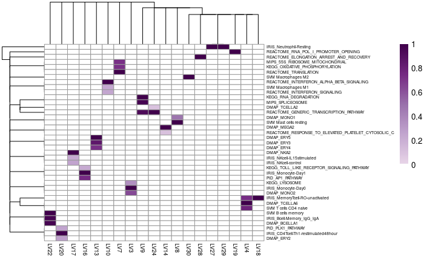

```r
PLIER::plotU(gpa.plier, fontsize_row = 5, fontsize_col = 7)
```

```r
pdf(file.path(plot.dir, "GPA_blood_U_plot.pdf"))
PLIER::plotU(gpa.plier, fontsize_row = 6, fontsize_col = 7)
dev.off()
```

`LV13` and `LV20` look like the most likely candidates, but we’ll look across all 30 LVs.

### Does an “autoantigen LV” exist in the GPA blood PLIER model?

```r
GetTopNGenes <- function(z.vector, num.genes = 50){
  names(head(sort(z.vector, decreasing = TRUE), num.genes))
}
top.genes <- apply(gpa.plier$Z, 2, GetTopNGenes)
ag.logical <- apply(top.genes, 2, function(x) any(x %in% autoantigens))
which(ag.logical)
```

```
[1] 8
```

```r
head(sort(gpa.plier$Z[, 8], decreasing = TRUE), 50)
```

```
      BPI     MS4A3       LTF   CEACAM8    CRISP3       MPO     DEFA4      CTSG    RNASE3      AZU1      TCN1      LCN2      MMP8     OLFM4   PCOLCE2    SLC2A5      OLR1    ABCA13
0.9707064 0.9598092 0.9155214 0.8608877 0.8515797 0.8488347 0.8485207 0.8324136 0.8207816 0.7919270 0.7917710 0.7556873 0.7221172 0.7180812 0.7051191 0.6897629 0.6747644 0.6720423
  COL17A1      CAMP      CD24    CLEC5A   SLC27A2     RAB13       MYB     CHIT1      FZD9    IQGAP3    ATP8B4     PRTN3     ANXA3      UGCG     ITGA9   CEACAM1      CPA3      TFF3
0.6650740 0.6411719 0.6063798 0.5667845 0.5408962 0.5173488 0.5107821 0.4932357 0.4925844 0.4906760 0.4532180 0.4408022 0.4116064 0.4034772 0.4016386 0.3982147 0.3774761 0.3647995
    CCNA1      SLPI    S100A9   SLC28A3    RNASE2      ANLN    MLF1IP     BUB1B     GATA2      POLE       SCD     POLE2     GPR84      ARG1
0.3644886 0.3601955 0.3562953 0.3509590 0.3489931 0.3414786 0.3402832 0.3372137 0.3315916 0.3287814 0.3194240 0.3157867 0.3126786 0.3098263
```

```r
# get into appropriate data.frame for bar plot
top.z.df <- as.data.frame(sort(gpa.plier$Z[, 8],
                               decreasing = TRUE)[1:50])
top.z.df <- tibble::rownames_to_column(top.z.df, var = "Gene")
colnames(top.z.df)[2] <- "Z"
# add in autoantigen information
top.z.df <- top.z.df %>%
  dplyr::mutate(Autoantigen =
                  dplyr::case_when(
                    Gene %in% autoantigens ~ "Yes",
                    TRUE ~ "No"
                  ))
# reorder for plotting
top.z.df$Gene <- factor(top.z.df$Gene,
                        levels = top.z.df$Gene[50:1])
```

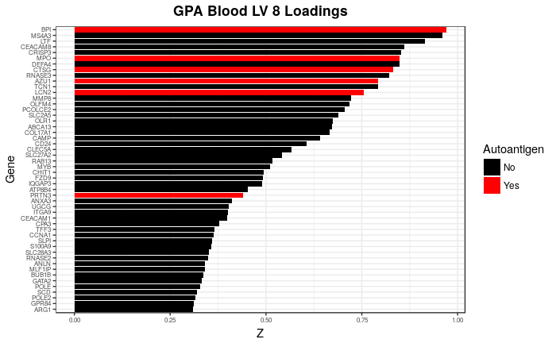

```r
p <- ggplot2::ggplot(top.z.df,
                ggplot2::aes(x = Gene, y = Z, fill = Autoantigen)) +
  ggplot2::geom_bar(stat = "identity") +
  ggplot2::theme_bw() +
  ggplot2::scale_fill_manual(values = c("black", "red")) +
  ggplot2::coord_flip() +
  ggplot2::ggtitle("GPA Blood LV 8 Loadings") +
  ggplot2::theme(plot.title = ggplot2::element_text(hjust = 0.5, face = "bold"))
p + ggplot2::theme(axis.text = ggplot2::element_text(size = 6))
```

```r
plot.file <- file.path(plot.dir, "GPA_blood_LV8_top_Z_bar.pdf")
ggplot2::ggsave(plot.file,
                plot = p +
                  ggplot2::theme(text = ggplot2::element_text(size = 15)),
                width = 6, height = 8)
```

`GPA blood LV 8` may be *most* similar to another recount2 LV like `recount2 LV 68`, which is also differentially expressed in this dataset. Let’s take a quick look at the top 50 genes for `recount2 LV 68`.

```r
head(sort(recount.plier$Z[, 68], decreasing = TRUE), 50)
```

```
 CEACAM8      BPI    DEFA4     CAMP     MMP8  PGLYRP1    MS4A3      LTF   RNASE3    PADI4     CTSG   CRISP3   ABCA13     AZU1    ELANE   RNASE2     FCAR     PRG2   S100A9     RGL4
7.887587 6.853320 6.817395 6.184177 5.051100 4.875414 4.569362 4.197822 4.136600 3.748623 3.221135 3.205522 2.930908 2.852379 2.545959 2.397721 2.305586 2.226229 2.222850 2.214754
  S100A8      CA1     SRGN   TRIM10    ITGAM     CST7    PLBD1     ARG1      CLC  SLCO4C1      LYZ  CEACAM1     BST1    ANXA3 SLC22A16     LCN2    PRTN3    PRAM1    EPB42      GP5
2.042006 1.985721 1.982392 1.942998 1.941000 1.921686 1.920328 1.843082 1.765571 1.685429 1.650977 1.572818 1.548932 1.534389 1.515435 1.509318 1.497583 1.344475 1.295891 1.280706
   OLFM4    CHIT1   CYP4F3      KEL SLC22A15   SLC2A5   CLTCL1    NLRC4     FCN1     GFI1
1.231628 1.148422 1.141577 1.133186 1.129168 1.057860 1.040496 1.035317 1.011179 0.994169
```

*By eye*, this looks more similar to `GPA blood LV 8`, but let’s do a more formal analysis.

### Compare to recount2 LVs

```r
# get Z matrices from both models
recount.z <- as.data.frame(recount.plier$Z)
gpa.z <- as.data.frame(gpa.plier$Z)
# we'll need to add the gene identifiers (symbols in this case) to a column
# rather than as rownames -- this will facilitate joining
recount.z <- tibble::rownames_to_column(recount.z, var = "Gene")
colnames(recount.z)[2:ncol(recount.z)] <- paste0("recountLV",
                                                 1:(ncol(recount.z) - 1))
gpa.z <- tibble::rownames_to_column(gpa.z, var = "Gene")
colnames(gpa.z)[2:ncol(gpa.z)] <- paste0("gpaLV", 1:(ncol(gpa.z) - 1))
# join -- only genes present in both models
z.df <- dplyr::inner_join(recount.z, gpa.z, by = "Gene")
# need matrix to calculate correlation
z.matrix <- as.matrix(z.df[, 2:ncol(z.df)])
rownames(z.matrix) <- z.df$Gene
```

```r
# calculate pearson correlation between LVs -- can we map between models using
# this distance metric?
cor.z.mat <- cor(z.matrix, method = "pearson")
# set diagonal to 0 to help find max correlation between LVs
diag(cor.z.mat) <- 0
# indices for each model
gpa.indx <- grep("gpa", rownames(cor.z.mat))
recount.indx <- grep("recount", rownames(cor.z.mat))
# pertinent indices
impt.cor.z.mat <- cor.z.mat[recount.indx, gpa.indx]
# for each GPA blood model LV, want the highest correlated LV from recount
mapping.df <- reshape2::melt(impt.cor.z.mat,
                              varnames = c("recount_LV", "GPA_blood_LV"),
                              value.name = "pearson_Z") %>%
                dplyr::group_by(GPA_blood_LV) %>%
                dplyr::top_n(1, pearson_Z)
mapping.df
```

| recount_LV | GPA_blood_LV | pearson_Z |
| --- | --- | --- |
| recountLV958 | gpaLV1 | 0.09531750 |
| recountLV3 | gpaLV2 | 0.11066103 |
| recountLV2 | gpaLV3 | 0.37161087 |
| recountLV954 | gpaLV4 | 0.38789638 |
| recountLV4 | gpaLV5 | 0.06917092 |
| recountLV835 | gpaLV6 | 0.09292739 |
| recountLV678 | gpaLV7 | 0.35643192 |
| recountLV68 | gpaLV8 | 0.60635214 |
| recountLV865 | gpaLV9 | 0.39154511 |
| recountLV116 | gpaLV10 | 0.62698179 |

[output cut: 20 more lines]

It looks like `GPA blood LV 8` does in fact map to `recount2 LV 68` as determined by taking the Pearson correlation between loadings.

#### Heatmap of mapping

We’ll select the top mapping LVs from the recount2 model as well as `recount2 LV 599` from `impt.cor.z.mat` for plotting as a heatmap.

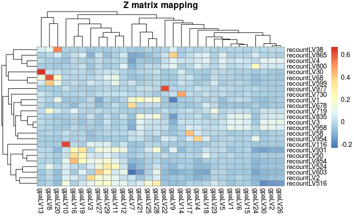

```r
plot.index <- which(rownames(impt.cor.z.mat) %in%
                      c(as.character(mapping.df$recount_LV), "recountLV599"))
heatmap.mat <- impt.cor.z.mat[plot.index, ]
pheatmap::pheatmap(heatmap.mat, main = "Z matrix mapping")
```

```r
plot.file <- file.path(plot.dir, "selected_cor_z_mat_heatmap.pdf")
pdf(plot.file)
pheatmap::pheatmap(heatmap.mat, main = "Z matrix mapping")
dev.off()
```

## Summary

Despite the lack of AAV expression data in the training compendium, the recount2 PLIER model learns a latent variable highly relevant to AAV. Specifically, `recount2 LV 599` captures a granulocyte progenitor signature. The top genes (as determined by the loadings, `Z`) are major (*PRTN3*, *MPO*) and minor (e.g., *AZU1*, *BPI*) autoantigens in ANCA-associated vasculitis.

We find an LV in the model specifically trained on the GPA blood dataset that also captures the activity autoantigens (`GPA blood LV 8`). However, the major autoantigens are not as highly ranked and this maps to another LV in the recount2 model, `recount2 LV 68`. This suggests that the recount2 model (e.g., the multiPLIER approach) can identify additional, highly relevant LVs.